# Dynamic control of enhancer activity drives stage-specific gene expression during flower morphogenesis | Nature Communications

### Enhancer dynamics drives stage-specific gene expression

To investigate how stage-specific enhancers, which were predicted based on distal intergenic DHSs, affect stage-specific gene-regulatory programs, we focused on the 810 distal intergenic DHSs whose accessibility varied at least 1.5 times among the four investigated floral stages. These dynamic enhancers were grouped into two distinct clusters based on their behavior in the time-course experiments (Fig. 6a; Supplementary Fig. 14 and Supplementary Data 5). Enhancers in cluster 1 were highly active at early stages but not at the later stage, while cluster 2 enhancers showed an opposite trend. For example, *UNUSUAL FLORAL ORGANS* (*UFO*) that is involved in specification of floral whorls in the meristem<sup>46</sup> is an enhancer-associated gene in cluster 1, while *AG* was identified to be a target gene of a cluster 2 enhancer (Fig. 6a). Overall, the dynamics of enhancers in the two clusters coincided well with the expression changes of their nearest-neighbor genes (Fig. 6b; Supplementary Fig. 15a). This observation was further supported by an analysis *per target gene*, in which the correlation between gene expression and chromatin accessibility at enhancer regions is significantly higher than that at promoters (paired Student’s *t* test < 0.05; Fig. 6c; Supplementary Fig. 15b). The above results indicate that enhancer dynamics has a strong impact on stage-specific gene expression during flower development.

**Fig. 6**

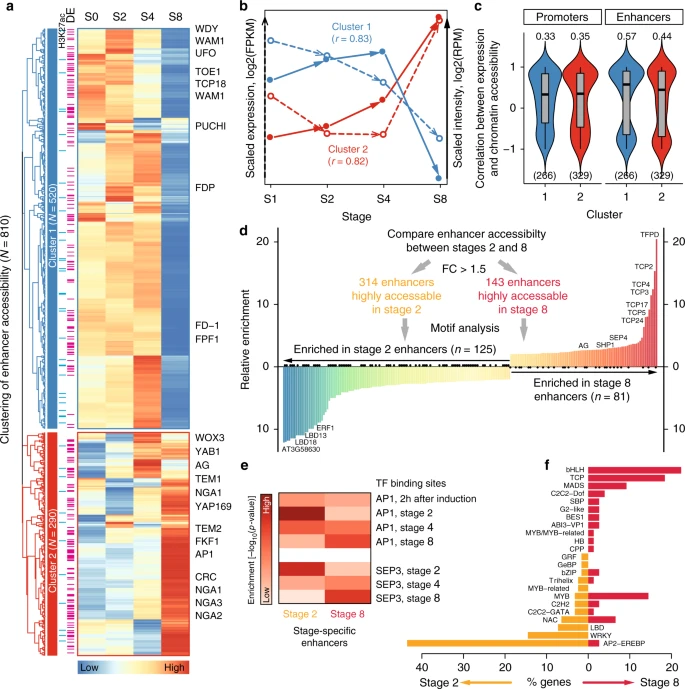

[Full size image](https://www.nature.com/articles/s41467-019-09513-2/figures/6)

In order to identify candidate TFs contributing to stage-specific activity of enhancers, we searched for potential TF DNA-binding sites making use of ChIP-seq data as well as motif scanning (Fig. 6d). We focused on the distal DHSs that showed at least 1.5 times difference in accessibility between 2 and 8 DAI. We first tested whether AP1 and SEP3, two major floral regulators for which the time-course ChIP-seq data are available<sup>18</sup>, bind to developmentally dynamic enhancers. Indeed, we found that AP1 and SEP3 bind to stage-specific enhancers in accordance with dynamic chromatin accessibility (Fig. 6e). We then searched for other TFs with known DNA-binding motifs that could bind to these stage-specific active enhancer candidates. We found that 125 and 81 TF-binding motifs showed a stronger enrichment (more than twofold in difference) in the active enhancers specific to 2 DAI and 8 DAI, respectively (Fig. 6d; Supplementary Data 5). For the highly active enhancers at 2 DAI, two LATERAL ORGAN BOUNDARIES DOMAIN (LBD) proteins, LBD18 and LBD13, were among the top-enriched binding TFs. AP2-EREBP and WRKY TF families predominantly bound at enhancers that were active at 2 DAI. Among the enhancers that were highly active at 8 DAI, the binding sites of basic helix–loop–helix proteins (bHLH) and TEOSINTE BRANCHED1, CYCLOIDEA, AND PCF TRANSCRIPTION FACTORS (TCP) proteins were overrepresented (Fig. 6d, f). The above results indicate that dynamic enhancers provide binding sites for potentially stage-specific TFs to drive gene expression.